# Differential gene expression analysis

Here we will perform differential gene expression analysis from raw `featureCounts` outputs using DESeq2.  
The workflow includes data import, quality exploration, transformation, dimensionality reduction, and differential testing between phenotypes.

**Note on sample size**: This analysis is based on only 4 samples (2 controls and 2 MDD). With such a small sample size, statistical power is limited, and it is unlikely to detect significant differentially expressed genes. The results should be interpreted cautiously, focusing on trends rather than definitive conclusions. For exploratory purposes, we will proceed with the analysis but highlight the limitations.

# 1 Input data

First, we read all count files and combine them into a count matrix. Rows correspond to genes and columns correspond to samples.

```r
# Read featureCounts outputs
files <- snakemake@input$counts
y <- readDGE(files, columns = c(1,7), comment.char = "#")
count_matrix <- y$counts

# Rename columns to sample IDs
colnames(count_matrix) <- gsub(".featureCounts.txt", "", basename(files))
head(count_matrix)
```

```
##                  Samples
## Tags              SRR30401469 SRR30401467 SRR30401459 SRR30401457
##   ENSG00000142611           0           0           0           0
##   ENSG00000284616           0           0           0           0
##   ENSG00000260972           0           0           0           0
##   ENSG00000229280           0           0           0           0
##   ENSG00000232596           0           0           0           0
##   ENSG00000231510           0           0           0           0
```

Next, we load sample metadata and define the phenotype reference level. Setting ‘ctrl’ as the reference ensures fold changes are interpreted relative to ‘ctrl’.

```r
samplesheet <- fread(snakemake@input$samplesheet)
samplesheet$phenotype <- relevel(factor(samplesheet$phenotype), ref="ctrl")
head(samplesheet)
```

```
##             ID phenotype
##         <char>    <fctr>
## 1: SRR30401469      ctrl
## 2: SRR30401467      ctrl
## 3: SRR30401459       mdd
## 4: SRR30401457       mdd
```

Now, we are ready to create a DESeq2 object from the count matrix and sample metadata using phenotype as the design variable.

```r
# make a DESeq2 object and explore it
dds <- DESeqDataSetFromMatrix(count_matrix,
                              colData = samplesheet,
                              design = ~ phenotype)
dds
```

```
## class: DESeqDataSet
## dim: 78899 4
## metadata(1): version
## assays(1): counts
## rownames(78899): ENSG00000142611 ENSG00000284616 ... ENSG00000309831
##   ENSG00000309258
## rowData names(0):
## colnames(4): SRR30401469 SRR30401467 SRR30401459 SRR30401457
## colData names(2): ID phenotype
```

# 2 Data exploration and visualisation

For exploratory analyses, we apply minimal filtering to include genes with some expression. This helps retain more genes for visualization while avoiding completely zero-expression genes.

```r
# Minimal filtering: keep genes expressed in at least 1 sample
keep <- rowSums(counts(dds) > 0) >= 1
dds_filt <- dds[keep, ]
summary(keep)
```

```
##    Mode   FALSE    TRUE
## logical   75588    3311
```

## 2.1 Counts

Let’s inspect the raw count distribution across samples using boxplots.

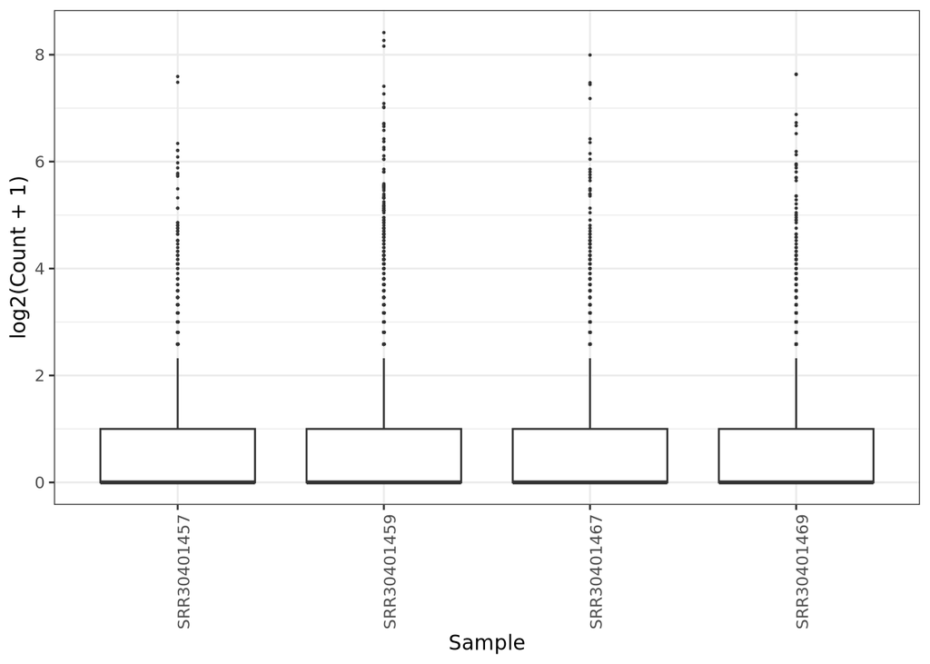

```r
melted_counts <- as.data.frame(counts(dds_filt)) %>%
  rownames_to_column("Gene") %>%
  pivot_longer(-Gene, names_to="ID", values_to="Count")

ggplot(melted_counts, aes(x=ID, y=log2(Count + 1))) +
  geom_boxplot(outlier.size=0.2) +
  theme_bw() +
  theme(axis.text.x = element_text(angle=90, hjust=1)) +
  labs(y="log2(Count + 1)", x="Sample")
```

## 2.2 Log transformation

We apply variance stabilizing transformation (VST) to reduce mean-variance dependence. This transformed matrix is used for PCA and heatmaps (but not the DEG analysis!).

```r
vsd <- varianceStabilizingTransformation(dds_filt, blind=FALSE)
```

```
## -- note: fitType='parametric', but the dispersion trend was not well captured by the
##    function: y = a/x + b, and a local regression fit was automatically substituted.
##    specify fitType='local' or 'mean' to avoid this message next time.
```

```r
vsd_counts <- assay(vsd)
head(vsd_counts)
```

```
##                 SRR30401469 SRR30401467 SRR30401459 SRR30401457
## ENSG00000149527    1.165888    1.165888    1.638515    1.759390
## ENSG00000280222    1.165888    1.165888    1.165888    1.759390
## ENSG00000189337    1.722327    1.165888    1.165888    1.165888
## ENSG00000116544    1.165888    1.732739    1.165888    1.759390
## ENSG00000116675    1.722327    1.165888    1.165888    1.165888
## ENSG00000286548    1.722327    1.165888    1.165888    1.165888
```

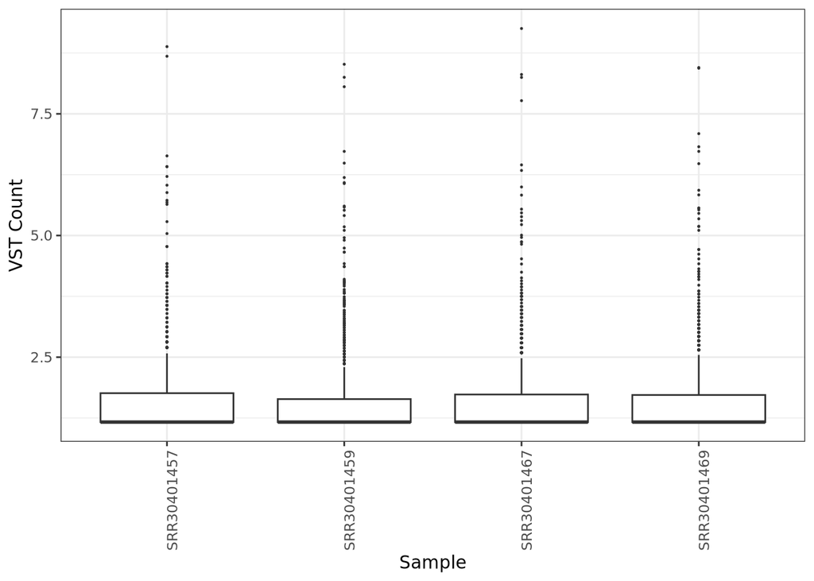

```r
melted_vsd <- as.data.frame(vsd_counts) %>%
  rownames_to_column("Gene") %>%
  pivot_longer(-Gene, names_to="ID", values_to="Count")

ggplot(melted_vsd, aes(x=ID, y=Count)) +
  geom_boxplot(outlier.size=0.2) +
  theme_bw() +
  theme(axis.text.x = element_text(angle=90, hjust=1)) +
  labs(y="VST Count", x="Sample")
```

## 2.3 Dispersion plot

```r
dds_filt <- estimateSizeFactors(dds_filt)
dds_filt <- estimateDispersions(dds_filt)
```

```
## -- note: fitType='parametric', but the dispersion trend was not well captured by the
##    function: y = a/x + b, and a local regression fit was automatically substituted.
##    specify fitType='local' or 'mean' to avoid this message next time.
```

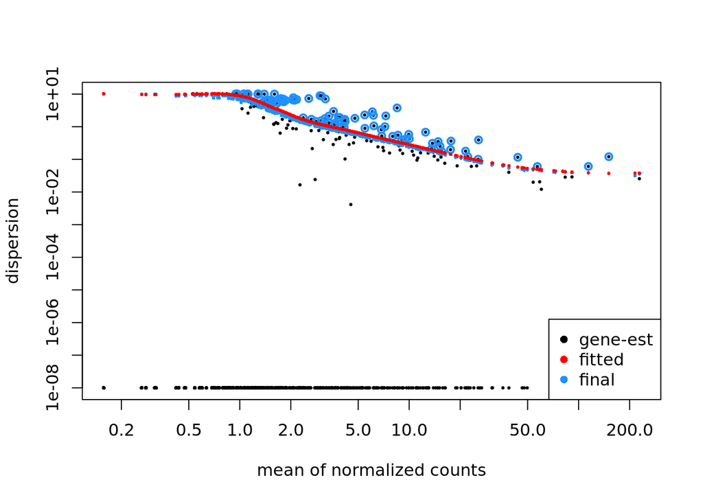

```r
plotDispEsts(dds_filt)
```

## 2.4 PCA

Principal component analysis provides an overview of sample-level structure and whether samples separate by phenotype.

```
## using ntop=500 top features by variance
```

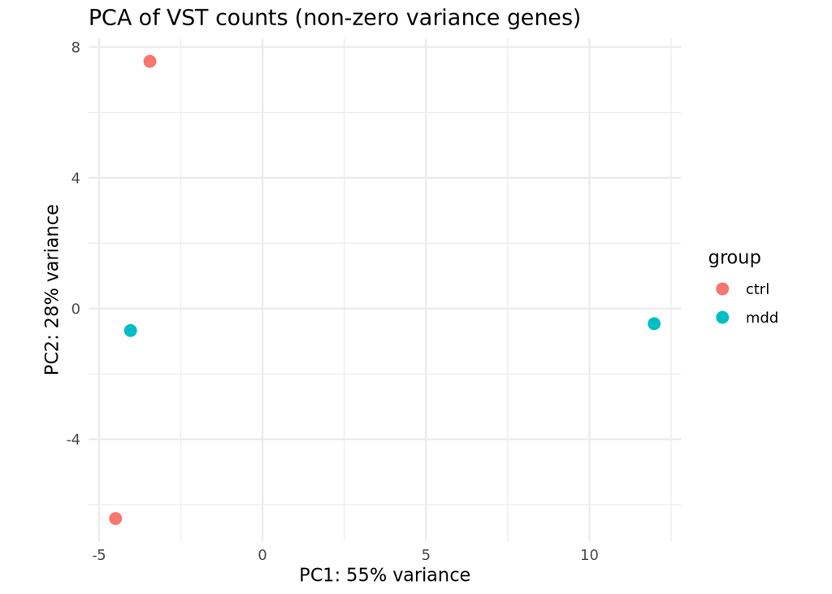

```r
vars <- rowVars(assay(vsd))
nonzero_var_genes <- names(vars[vars > 0])

# Create PCA using only non-zero variance genes
plotPCA(vsd[nonzero_var_genes, ], intgroup="phenotype") +
  theme_minimal() +
  ggtitle("PCA of VST counts (non-zero variance genes)")
```

## 2.5 Top 500 most variable gene expression

We select the 500 most variable genes and visualize their expression patterns across samples in a heatmap. This way we can easily explore if our phenotype shows any specific patterns or raises concerns prior to DEG analysis.

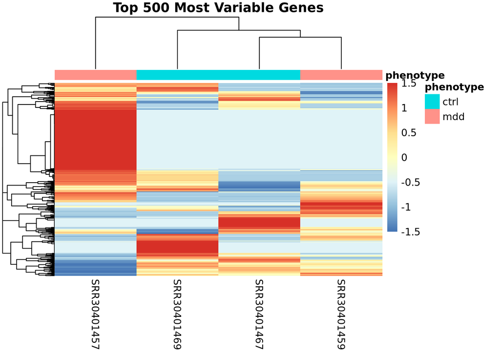

```r
n_top <- min(500, length(nonzero_var_genes))
top_genes <- nonzero_var_genes[order(vars[nonzero_var_genes], decreasing=TRUE)[1:n_top]]

mat <- assay(vsd)[top_genes, ]
ann_col <- as.data.frame(colData(vsd)[, "phenotype", drop=FALSE])

pheatmap(mat, scale="row", show_rownames=FALSE,
         annotation_col=ann_col,
         cluster_cols=TRUE,
         main=paste("Top", n_top, "Most Variable Genes"))
```

## 2.6 Sample distance heatmap

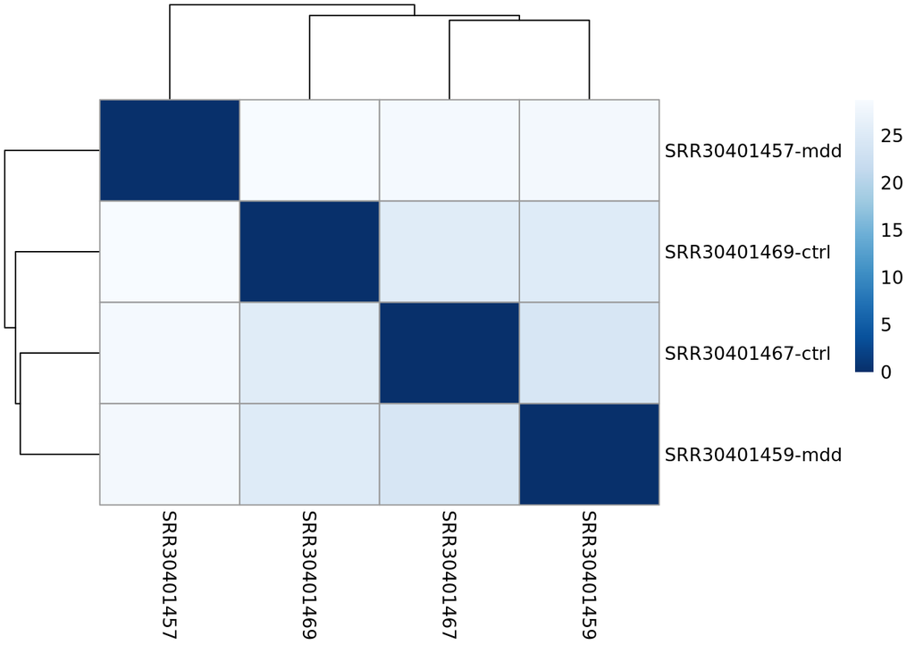

```r
sampleDists <- dist(t(assay(vsd)))
sampleDistMatrix <- as.matrix(sampleDists)
rownames(sampleDistMatrix) <- paste(vsd$ID, vsd$phenotype, sep="-")
colors <- colorRampPalette(rev(brewer.pal(9, "Blues")))(255)

pheatmap(sampleDistMatrix,
         clustering_distance_rows=sampleDists,
         clustering_distance_cols=sampleDists,
         col=colors)
```

# 3 Differential gene expression

Now, we are ready to run the DESeq2 model and extract differential expression results for MDD versus control.

```r
dds_filt <- DESeq(dds_filt)
```

```
## found already estimated dispersions, replacing these
```

```
## -- note: fitType='parametric', but the dispersion trend was not well captured by the
##    function: y = a/x + b, and a local regression fit was automatically substituted.
##    specify fitType='local' or 'mean' to avoid this message next time.
```

```r
res <- results(dds_filt, contrast=c("phenotype","mdd","ctrl"))
summary(res)
```

```
##
## out of 3311 with nonzero total read count
## adjusted p-value < 0.1
## LFC > 0 (up)       : 0, 0%
## LFC < 0 (down)     : 0, 0%
## outliers [1]       : 0, 0%
## low counts [2]     : 0, 0%
## (mean count < 0)
## [1] see 'cooksCutoff' argument of ?results
## [2] see 'independentFiltering' argument of ?results
```

Shrinkage of effect size (LFC estimates) is useful for visualization and ranking of genes. To shrink the LFC, we pass the dds object to the function lfcShrink

```r
resLFC <- lfcShrink(dds_filt, coef="phenotype_mdd_vs_ctrl", type="apeglm")
```

```
## using 'apeglm' for LFC shrinkage. If used in published research, please cite:
##     Zhu, A., Ibrahim, J.G., Love, M.I. (2018) Heavy-tailed prior distributions for
##     sequence count data: removing the noise and preserving large differences.
##     Bioinformatics. https://doi.org/10.1093/bioinformatics/bty895
```

```r
resLFC
```

```
## log2 fold change (MAP): phenotype mdd vs ctrl
## Wald test p-value: phenotype mdd vs ctrl
## DataFrame with 3311 rows and 5 columns
##                  baseMean log2FoldChange      lfcSE    pvalue      padj
##                 <numeric>      <numeric>  <numeric> <numeric> <numeric>
## ENSG00000149527  0.477760    1.26374e-07 0.00144270  0.629216  0.959349
## ENSG00000280222  0.320283    1.02375e-07 0.00144270  0.752327  0.959349
## ENSG00000189337  0.263523   -1.05570e-07 0.00144270  0.733182  0.959349
## ENSG00000116544  0.599481    2.51082e-09 0.00144269  0.986414  0.990303
## ENSG00000116675  0.263523   -1.05570e-07 0.00144270  0.733182  0.959349
## ...                   ...            ...        ...       ...       ...
## ENSG00000275757 12.487993   -7.35048e-08 0.00144269  0.924552  0.990303
## ENSG00000310376  3.987754    8.84732e-07 0.00144269  0.198046  0.959349
## ENSG00000296598  0.263523   -1.05570e-07 0.00144270  0.733182  0.959349
## ENSG00000296634  0.157476    8.57515e-08 0.00144270  0.834179  0.959349
## ENSG00000273730  0.320283    1.02375e-07 0.00144270  0.752327  0.959349
```

```r
top_genes <- resLFC %>%
  as.data.frame() %>%
  rownames_to_column("Gene") %>%
  arrange(padj) %>%
  slice_head(n=10)

top_genes
```

```
##               Gene  baseMean log2FoldChange       lfcSE    pvalue     padj
## 1  ENSG00000149527 0.4777596   1.263744e-07 0.001442695 0.6292160 0.959349
## 2  ENSG00000280222 0.3202834   1.023747e-07 0.001442695 0.7523265 0.959349
## 3  ENSG00000189337 0.2635231  -1.055696e-07 0.001442695 0.7331815 0.959349
## 4  ENSG00000116675 0.2635231  -1.055696e-07 0.001442695 0.7331815 0.959349
## 5  ENSG00000286548 0.2635231  -1.055696e-07 0.001442695 0.7331815 0.959349
## 6  ENSG00000234975 0.2791974  -1.068308e-07 0.001442695 0.7266980 0.959349
## 7  ENSG00000285718 0.1574762   8.575146e-08 0.001442695 0.8341787 0.959349
## 8  ENSG00000277007 0.3202834   1.023747e-07 0.001442695 0.7523265 0.959349
## 9  ENSG00000207181 0.2791974  -1.068308e-07 0.001442695 0.7266980 0.959349
## 10 ENSG00000143627 0.2635231  -1.055696e-07 0.001442695 0.7331815 0.959349
```

## 3.2 Visualisation of most significant DEGs

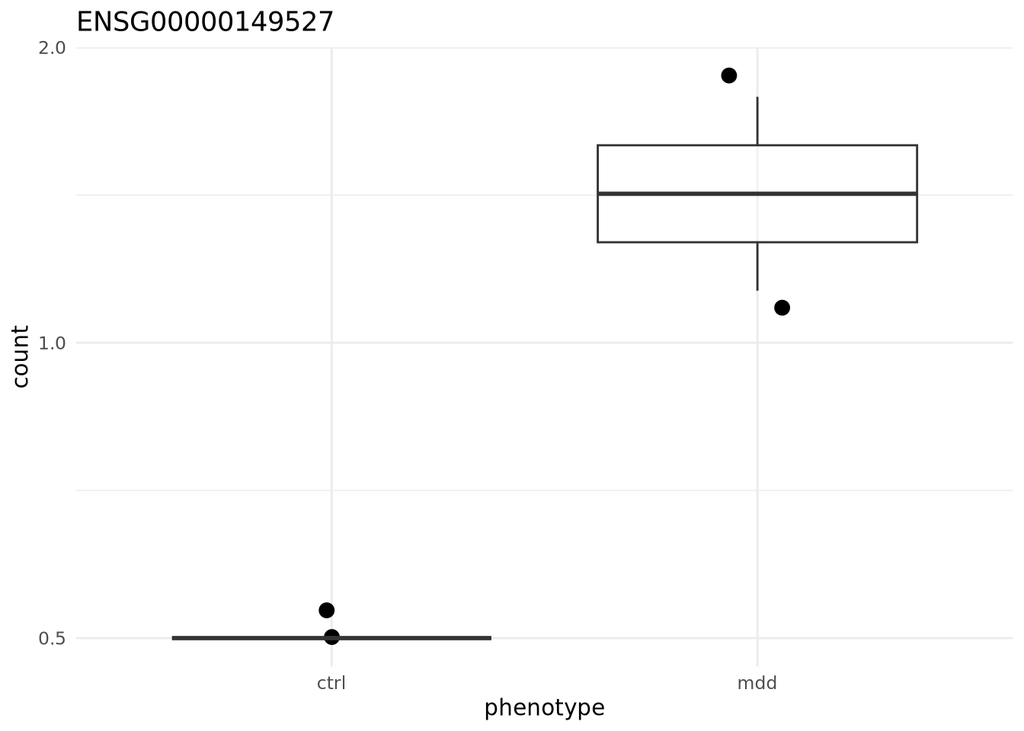

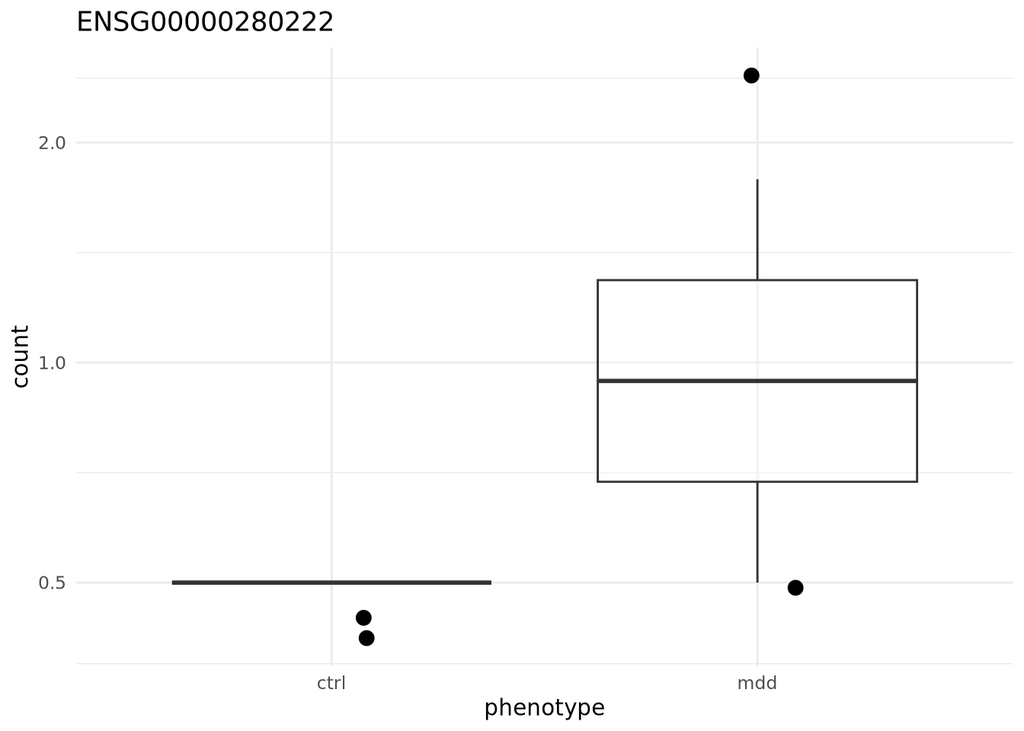

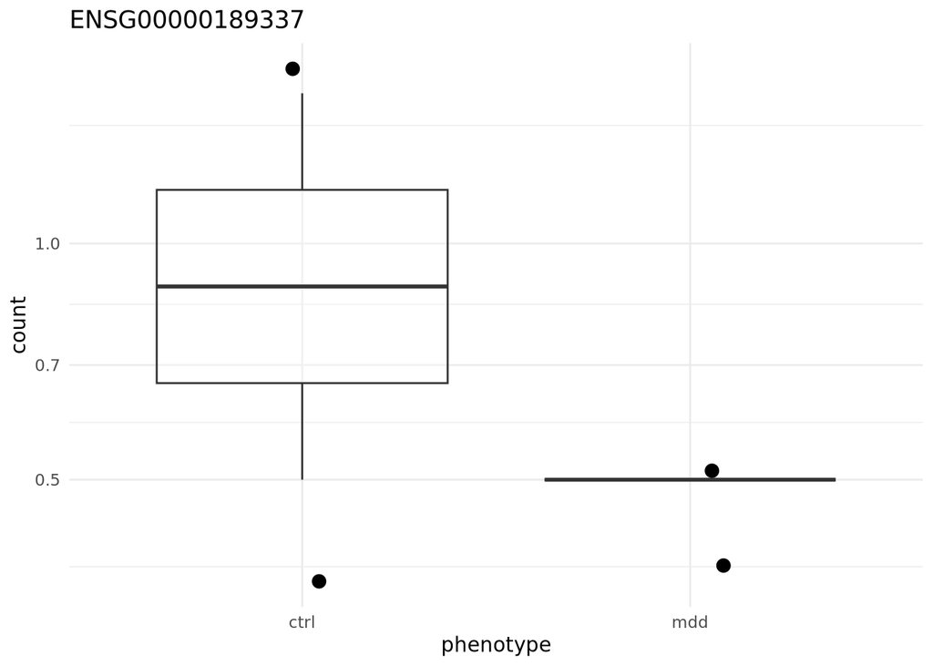

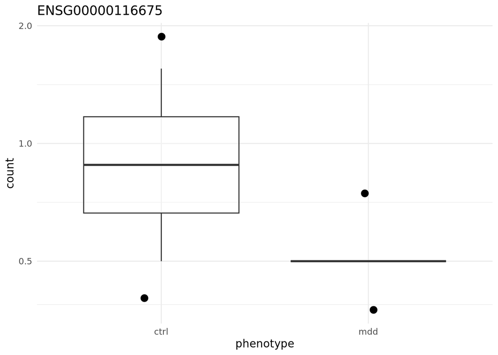

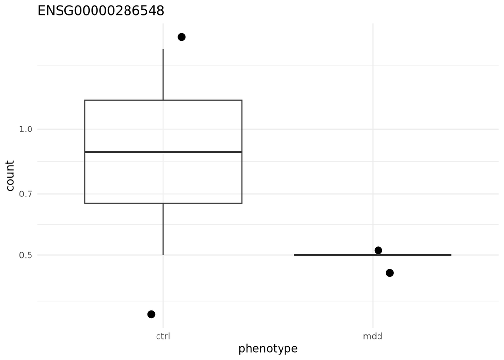

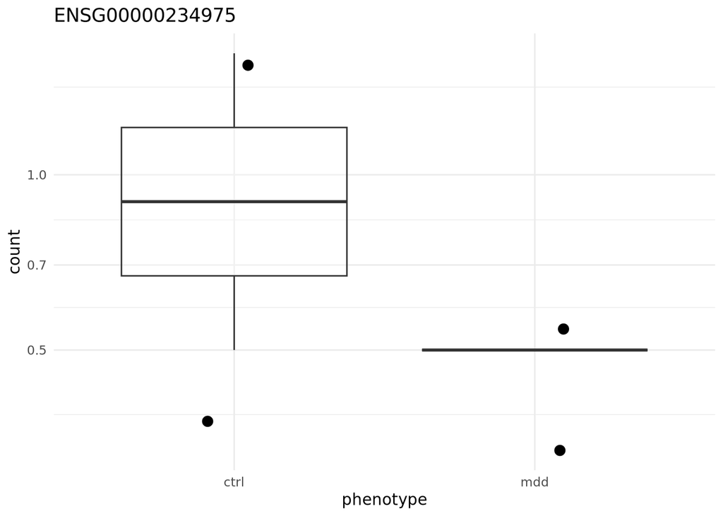

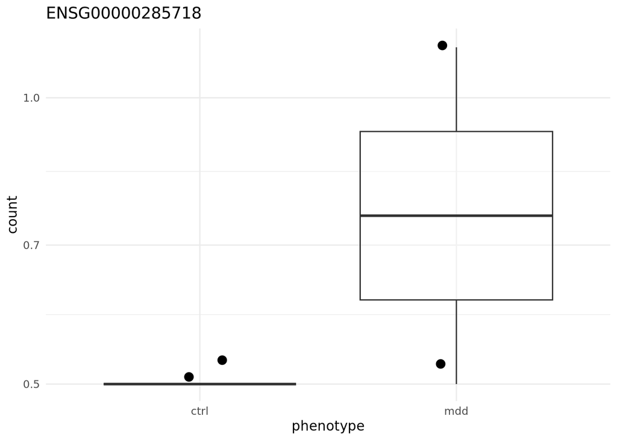

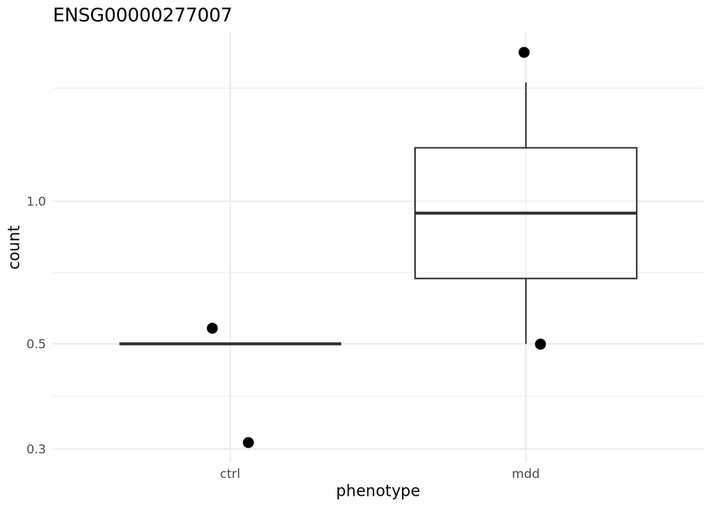

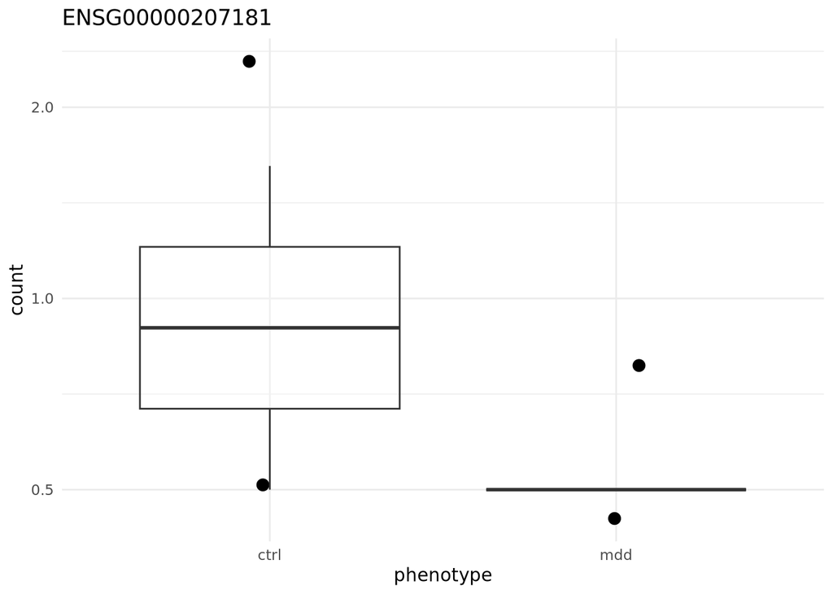

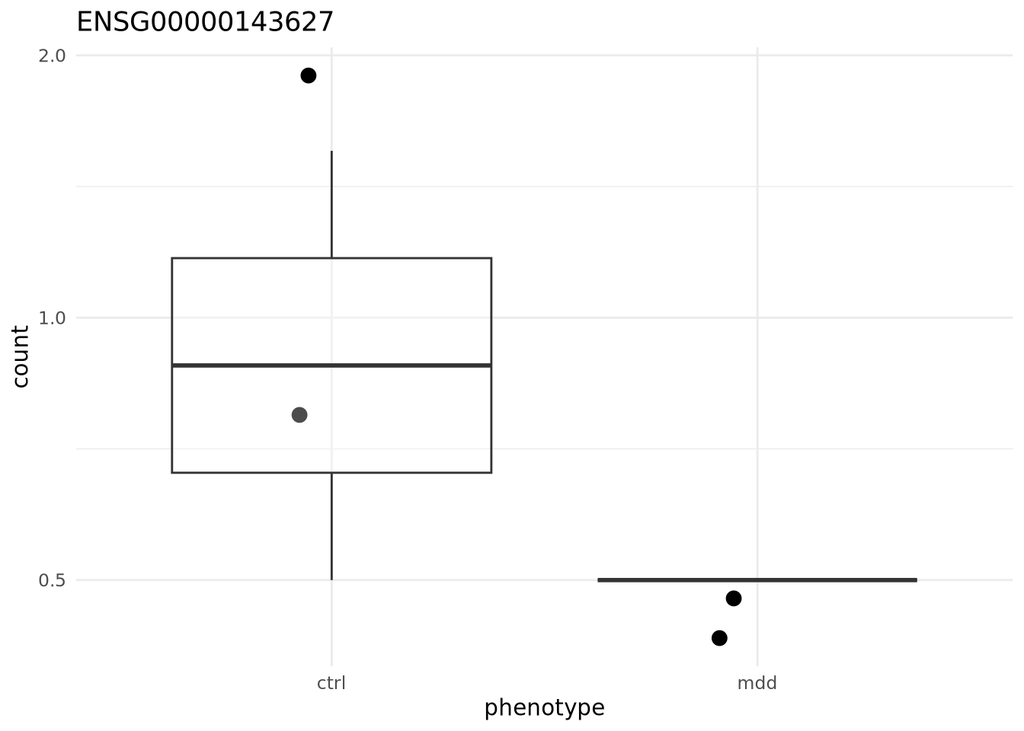

```r
plot_gene <- function(gene){
  df <- plotCounts(dds_filt, gene=gene, intgroup="phenotype", returnData=TRUE)
  ggplot(df, aes(x=phenotype, y=count)) +
    geom_jitter(width=0.1, size=3) +
    geom_boxplot(alpha=0.3, outlier.shape=NA) +
    scale_y_log10() +
    theme_minimal() +
    ggtitle(gene)
}

for(g in top_genes$Gene){
  print(plot_gene(g))
}
```

## 3.3 Volcano plot

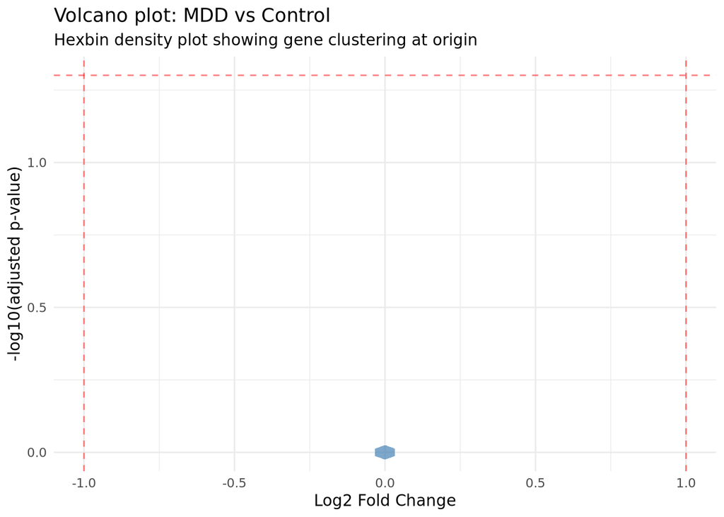

```r
res_df <- resLFC %>% as.data.frame() %>% rownames_to_column("Gene") %>%
  mutate(Significant = padj < 0.05 & abs(log2FoldChange) > 1) %>%
  filter(!is.na(padj), !is.na(log2FoldChange))

# Replace any Inf values with a large number
res_df$neg_log10_padj <- -log10(pmax(res_df$padj, 1e-300))
res_df$neg_log10_padj[is.infinite(res_df$neg_log10_padj)] <- max(res_df$neg_log10_padj[is.finite(res_df$neg_log10_padj)]) + 1

# Use hexbin plot to visualize point density since points are concentrated at origin
p <- ggplot(res_df, aes(x=log2FoldChange, y=neg_log10_padj)) +
  geom_hex(bins=30, fill="steelblue", alpha=0.7) +
  scale_fill_gradient(trans="log10", low="lightblue", high="darkblue") +
  geom_vline(xintercept=c(-1,1), linetype="dashed", color="red", alpha=0.5) +
  geom_hline(yintercept=-log10(0.05), linetype="dashed", color="red", alpha=0.5) +
  theme_minimal() +
  theme(legend.position = "right") +
  labs(title="Volcano plot: MDD vs Control",
       subtitle="Hexbin density plot showing gene clustering at origin",
       x="Log2 Fold Change",
       y="-log10(adjusted p-value)",
       fill="Gene count")

print(p)
```

**Analysis**: With only 4 samples, there is virtually no measurable differential expression: - **Log2 Fold Changes**: Range from -6×10⁻⁶ to +5×10⁻⁶ (essentially zero) - **-log10(padj)**: Range from 0.000015 to 0.018 (all p-values ≈ 1) - **Result**: All 3,311 genes cluster at the origin with no significant hits

This is expected biological noise with insufficient replication. To detect true DEGs, you would need substantially more samples per condition (typically ≥3-4 per group minimum, preferably more).

# 4 Pathway analysis

**Note**: Pathway analysis with GSEA may not yield meaningful results with only 4 samples and no significant DEGs. Results should be interpreted as exploratory only.

## 4.1 GSEA with fgsea

```r
msig_human <- msigdbr::msigdbr(species = "Homo sapiens", collection = "C5") %>%
  dplyr::select(gs_name, ensembl_gene) %>%   # explicitly call dplyr::select
  dplyr::filter(!is.na(ensembl_gene), ensembl_gene != "") %>%
  dplyr::distinct()

pathways <- split(msig_human$ensembl_gene, msig_human$gs_name)

clean_ids <- sub("\\..*", "", rownames(resLFC))
ranks <- resLFC$log2FoldChange
names(ranks) <- clean_ids
ranks <- sort(na.omit(ranks), decreasing=TRUE)

fg <- fgsea(pathways=pathways, stats=ranks, minSize=15, maxSize=500) %>%
  as_tibble() %>% arrange(padj)
head(fg[,c("pathway","NES","pval","padj")], 20)
```

```
## # A tibble: 20 × 4
##    pathway                                             NES    pval  padj
##    <chr>                                             <dbl>   <dbl> <dbl>
##  1 GOMF_NUCLEOSIDE_TRIPHOSPHATASE_REGULATOR_ACTIVITY -1.77 0.0109  0.458
##  2 HP_ABNORMALITY_OF_CORNEAL_SIZE                     1.91 0.0101  0.458
##  3 HP_ABNORMALITY_OF_THE_GALLBLADDER                  1.95 0.00934 0.458
##  4 HP_ABNORMALITY_OF_THE_OVARY                        2.00 0.00312 0.458
##  5 HP_ABNORMALITY_OF_THE_PULMONARY_ARTERY             1.95 0.00975 0.458
##  6 HP_ABNORMAL_CAROTID_ARTERY_MORPHOLOGY              1.98 0.00497 0.458
##  7 HP_ABNORMAL_DIMINISHED_VOLITION                    1.86 0.00175 0.458
##  8 HP_ABNORMAL_GALLBLADDER_MORPHOLOGY                 1.98 0.00848 0.458
##  9 HP_ABNORMAL_HEAD_BLOOD_VESSEL_MORPHOLOGY           2.13 0.00188 0.458
## 10 HP_ABNORMAL_LOCALIZATION_OF_KIDNEY                 1.87 0.0108  0.458
## 11 HP_ABNORMAL_MALE_REPRODUCTIVE_SYSTEM_PHYSIOLOGY    1.88 0.00872 0.458
## 12 HP_ABNORMAL_MITRAL_VALVE_PHYSIOLOGY                1.84 0.00831 0.458
## 13 HP_ABNORMAL_OVARIAN_MORPHOLOGY                     2.16 0.00122 0.458
## 14 HP_ABNORMAL_PATELLA_MORPHOLOGY                     2.02 0.00382 0.458
## 15 HP_ABNORMAL_PYRAMIDAL_TRACT_MORPHOLOGY             2.04 0.00313 0.458
## 16 HP_ABNORMAL_RECTUM_MORPHOLOGY                      1.98 0.00822 0.458
## 17 HP_ABNORMAL_RENAL_TUBULE_MORPHOLOGY                1.96 0.00650 0.458
## 18 HP_ABNORMAL_SHOULDER_MORPHOLOGY                    2.00 0.00444 0.458
## 19 HP_ABNORMAL_SIZE_OF_THE_PALPEBRAL_FISSURES         1.84 0.00907 0.458
## 20 HP_ABNORMAL_TOENAIL_MORPHOLOGY                     1.92 0.00708 0.458
```

## 4.2 Visualisation of top pathways

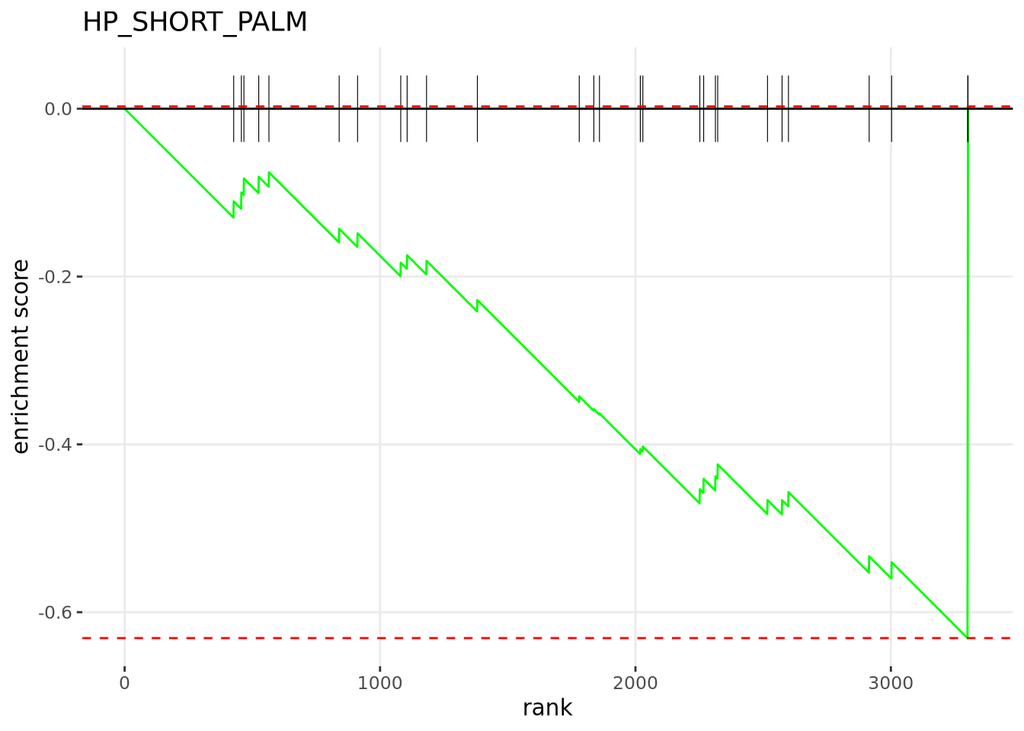

```r
# Only plot if there are pathways with NES
if(nrow(fg) > 0){
  high_nes <- fg[order(-fg$NES),]$pathway[1]
  plotEnrichment(pathways[[high_nes]], ranks) + labs(title=high_nes)

  low_nes <- fg[order(fg$NES),]$pathway[1]
  plotEnrichment(pathways[[low_nes]], ranks) + labs(title=low_nes)
} else {
  message("No pathways found for enrichment plots.")
}
```

## 4.3 Dotplot of top pathways

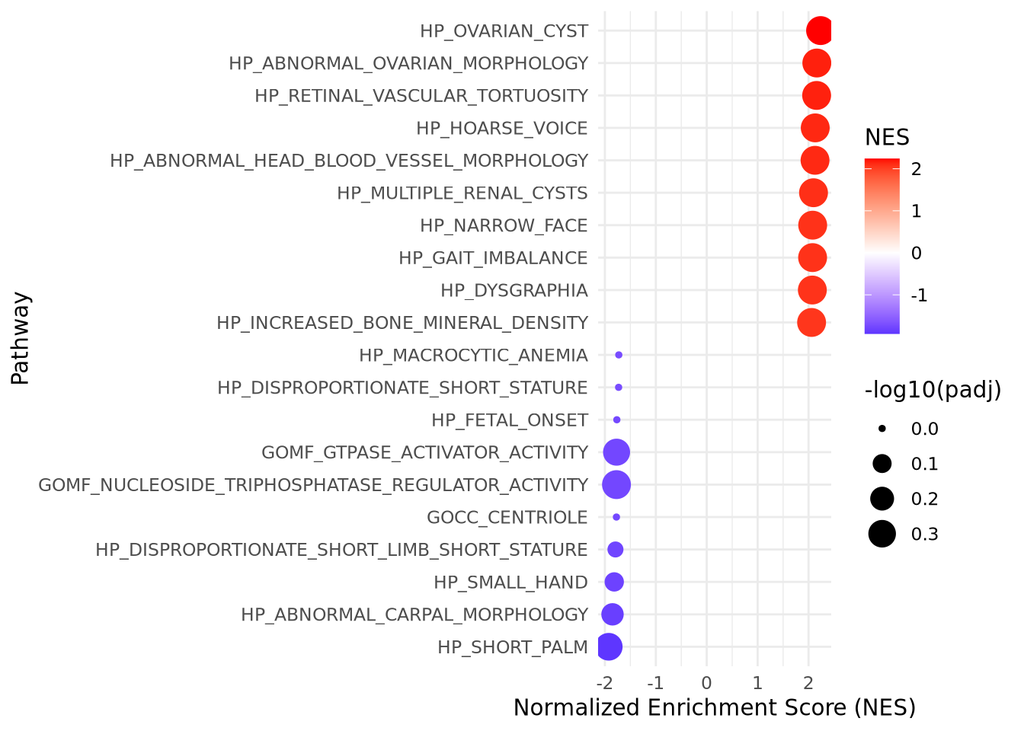

```r
top_pos <- fg %>% filter(NES>0) %>% slice_max(NES, n=10)
top_neg <- fg %>% filter(NES<0) %>% slice_min(NES, n=10)
top_pathways <- bind_rows(top_pos, top_neg) %>% arrange(NES)

ggplot(top_pathways, aes(x=NES, y=reorder(pathway, NES), size=-log10(padj), color=NES)) +
  geom_point() +
  scale_color_gradient2(low="blue", mid="white", high="red", midpoint=0) +
  theme_minimal() +
  labs(x="Normalized Enrichment Score (NES)", y="Pathway", size="-log10(padj)")
```